# Bitcoin Price Time Series Analysis

Last updated: 2024-04-14

## Preliminary Work: Install/Load Packages

To try and ensure that this R Notebook will run successfully, we’ll use the [renv package](https://cran.r-project.org/web/packages/renv/index.html) to create a project-specific library of packages. This will allow us to install the packages that we need for this project without affecting any other projects that we may be working on. Additionally, the project library will track the specific versions of the dependency packages so that any updates to those packages will not break this project.

The code chunk below will first install the renv package if it is not already installed. Then we will load the package. Next, we’ll use the `restore()` function to install any packages listed in the renv.lock file. Once these packages are installed, we can load them into the R session using the `library()` commands. Below the code chunk, we’ll list out the packages that will be used in the project demo. And if you run into any trouble using renv, then you can use the second code chunk below and that should be an even more reliable approach to install the required packages.

```r
# Install renv package if not already installed
if(!"renv" %in% installed.packages()[,"Package"]) install.packages("renv")
# Load renv package
library(renv)
# Use restore() to install any packages listed in the renv.lock file
renv::restore(clean=TRUE, lockfile="../renv.lock")
# Load in the packages
library(quantmod)
library(tseries)
library(ggplot2)
library(seasonal)
library(seasonalview)
library(rmarkdown)
library(stringr)
```

- The [quantmod package](https://cran.r-project.org/package=quantmod) contains tools for importing and analyzing financial data.
- The [ggplot2 package](https://cran.r-project.org/package=ggplot2) for graphics and visuals.
- The [tseries package](https://cran.r-project.org/package=tseries) contains additional time series analysis functions that we will explore.
- The [seasonal package](https://cran.r-project.org/package=seasonal) contains an interface to the [Census X-13-ARIMA-SEATS model](https://www.census.gov/data/software/x13as.html).
- The [seasonalview package](https://cran.r-project.org/package=seasonalview) brings a graphical user interface to that Census model.
- The [rmarkdown package](https://cran.r-project.org/package=rmarkdown) is used to generate this R Notebook.
- The [stringr package](https://cran.r-project.org/package=stringr) is another package used by R Markdown to compile R Notebooks.

Since the rmarkdown functionality is built into RStudio, this last one is automatically loaded when you open RStudio. So no need to use the `library()` function for it. Another observation to make about the code chunk above is that it is labeled as `setup`, which is a special name, which the R Notebook will recognize and automatically run prior to running any other code chunk. This is useful for loading in packages and setting up other global options that will be used throughout the notebook.

Then if you wish to try and update the versions of the various R packages in the lock file, you can use the `renv::update()` function to update the packages in the project library. However, it is possible that these updates could break the code in this notebook. If so, you may need to adapt the code to work with the updated packages.

My recommendation is to first run through the code using the versions of the packages in the lock file. Then if you want to try and update the packages, you can do so and then run through the code again to see if it still works. If not, you can always revert back to the lock file versions using the `renv::restore()` function.

If you update the packages and get everything working successfully, then you can update the lock file using the `renv::snapshot()` function. This will update the lock file with the versions of the packages that are currently installed in the project library. Then you can commit the updated lock file to the repository so that others can use the updated versions of the packages.

### Alternative Package Installation Code

If you run into any trouble using renv in the code chunk above, then you can use the code chunk below to install the required packages for this analysis. This method will first check if you have already installed the packages. If any are missing, it will then install them. Then it will load the packages into the R session. A potential flaw in this approach compared to using renv is that it will simply install the latest versions of the packages, which could potentially break some of the code in this notebook if any of the updates aren’t backwards compatible.

As long as you have downloaded the entire project repository, the renv chunk above will likely be managing the packages. Thus, the `eval=FALSE` option is used to prevent this chunk from running unless manually executed. So if you only downloaded this one Rmd file, this code chunk should take care of installing the packages for you.

```r
# Create list of packages needed for this exercise, omit geckor since its not on CRAN
list.of.packages = c("quantmod","ggplot2","tseries","seasonal","seasonalview","rmarkdown","stringr")
# Check if any have not yet been installed
new.packages = list.of.packages[!(list.of.packages %in% installed.packages()[,"Package"])]
# If any need to be installed, install them
if(length(new.packages)) install.packages(new.packages)
# Since geckor is no longer published to CRAN, install via GitHub
library(quantmod)
library(tseries)
library(ggplot2)
library(seasonal)
library(seasonalview)
library(rmarkdown)
library(stringr)
```

## Bitcoin Data Import and Cleaning

The `getSymbols()` function from the quantmod package let’s us import the daily price data for bitcoin. The `src="yahoo"` argument specifies that we want to pull the data from Yahoo Finance. The `from` and `to` arguments specify the date range for the data, which goes back to October 2014 for bitcoin. Rather that assigning a variable name to the output of `getSymbols()`, the function creates a new variable for each ticker in the list, named after the ticker. For bitcoin in particular, the `"BTC-USD"` can be tedious to work with since the presence of a dash requires one to wrap the variable name in backticks. This is resolved in the last line of the code chunk below by creating a new variable `BTC` to be used instead.

```r
startdate = "2014-10-01"
tickers = c("BTC-USD")
getSymbols(tickers,
           src="yahoo",
           from=startdate,
           to=Sys.Date())
BTC = `BTC-USD`
```

Now that we have the daily bitcoin price series, let’s extract the close prices into a univariate xts object. Then we can rename the column to `"Close"` to keep variable names simple. After that, let’s aggregate the daily prices to weekly and monthly series to compare the time series properties at different frequencies. The xts package (which is a dependency of quantmod) allows us to easily convert the daily price data into weekly or monthly OHLC series using `to.weekly()` and `to.monthly()`. The `name=NULL` option in those functions prevents the variable names from including the name of the original object. So instead of `` BTCweeksOHLC2$``BTCdaily$Close.Close`` ``, we can just use `BTCweeksOHLC$Close`.

```r
# Create daily series and rename column
BTCdaily = BTC$`BTC-USD.Close`
names(BTCdaily) = "Close"
# Convert to weekly and monthly series
BTCweeksOHLC = to.weekly(BTCdaily$Close, name=NULL)
BTCweeks = BTCweeksOHLC$Close
BTCmonthOHLC = to.monthly(BTCdaily$Close, name=NULL)
BTCmonth = BTCmonthOHLC$Close
```

## Exploring the Full Bitcoin Price Series

### Basic Price Charts

We’ll start with some simple plots of the BTC price series that we downloaded. Starting with the daily chart, then weekly and monthly.

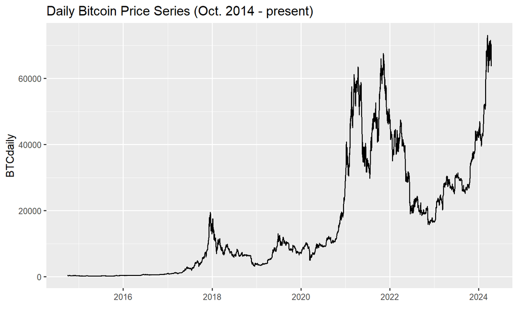

```r
ggplot() +
  geom_line(aes(x=index(BTCdaily),y=BTCdaily)) +
  xlab("") +
  ggtitle("Daily Bitcoin Price Series (Oct. 2014 - present)")
```

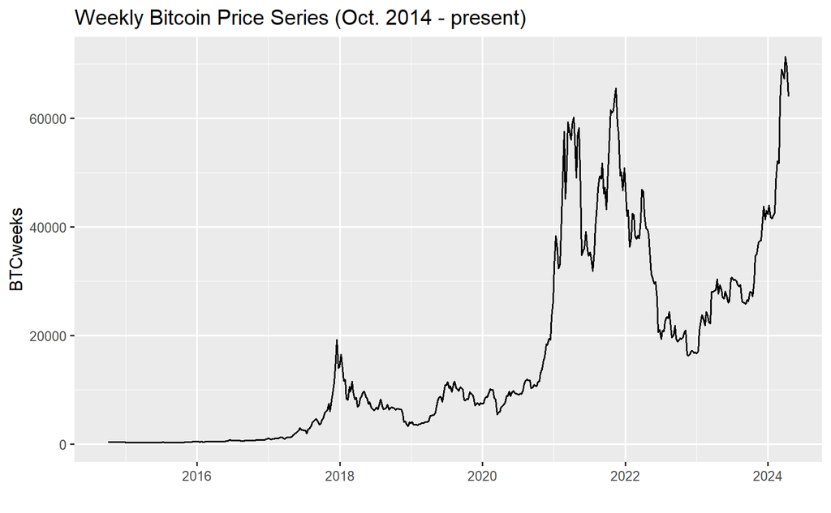

```r
ggplot() +
  geom_line(aes(x=index(BTCweeks),y=BTCweeks)) +
  xlab("") +
  ggtitle("Weekly Bitcoin Price Series (Oct. 2014 - present)")
```

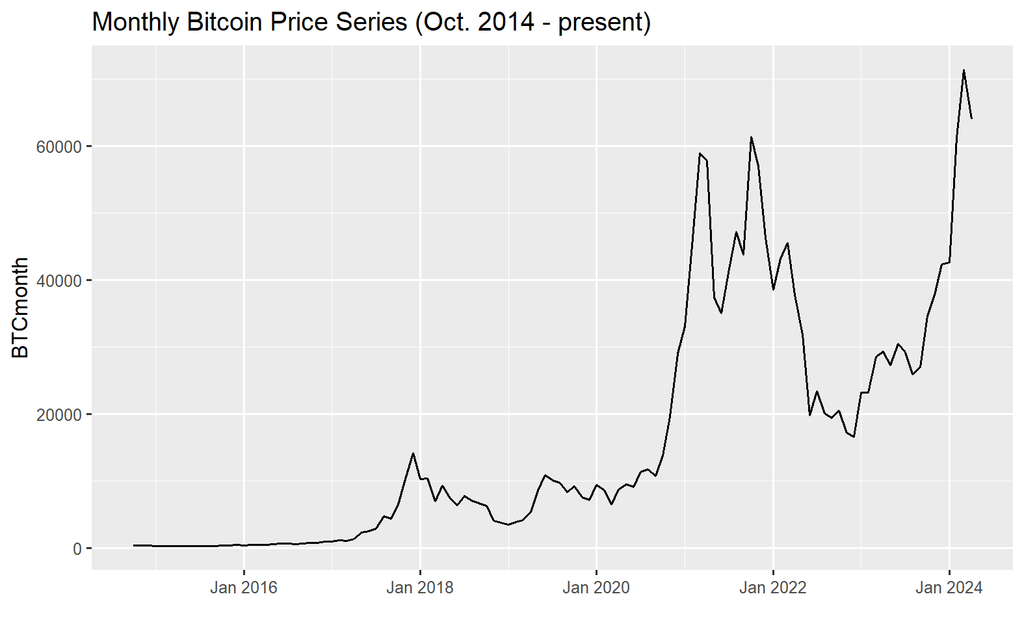

```r
ggplot() +
  geom_line(aes(x=index(BTCmonth),y=BTCmonth)) +
  xlab("") +
  ggtitle("Monthly Bitcoin Price Series (Oct. 2014 - present)")
```

### Log Price Charts

In regard to statistical analysis of time series data, one drawback of the price series above is that they are non-stationary. This will be explored in more detail below, but it is visually depicted in the plots above through the observation that the mean value of the series is not constant over time. To resolve this, we can convert the price series to a stationary process by effectively taking its derivative. By using log returns, we effectively assume continuous compounding of the price series, which reflects the 24/7 365 nature of cryptocurrency markets.

$$r_t = \ln(P_t) - \ln(P_{t-1}) =
\ln\left(\dfrac{P_t}{P_{t-1}}\right)$$

The first step in calculating continuously compounded growth rates is to take the natural logarithm of the prices. To visualize this transformation, let’s apply two approaches for plotting out the logged price charts. The first approach is to simply compute the log(prices) within the ggplot specifications:

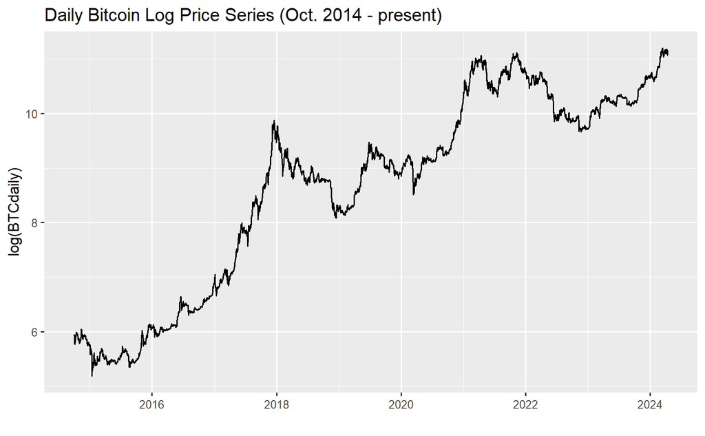

```r
ggplot() +
  geom_line(aes(x=index(BTCdaily), y=log(BTCdaily))) +
  xlab("") +
  ggtitle("Daily Bitcoin Log Price Series (Oct. 2014 - present)")
```

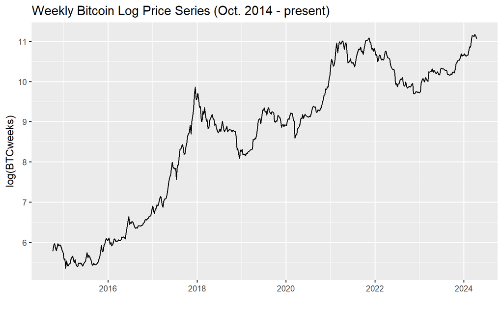

```r
ggplot() +
  geom_line(aes(x=index(BTCweeks), y=log(BTCweeks))) +
  xlab("") +
  ggtitle("Weekly Bitcoin Log Price Series (Oct. 2014 - present)")
```

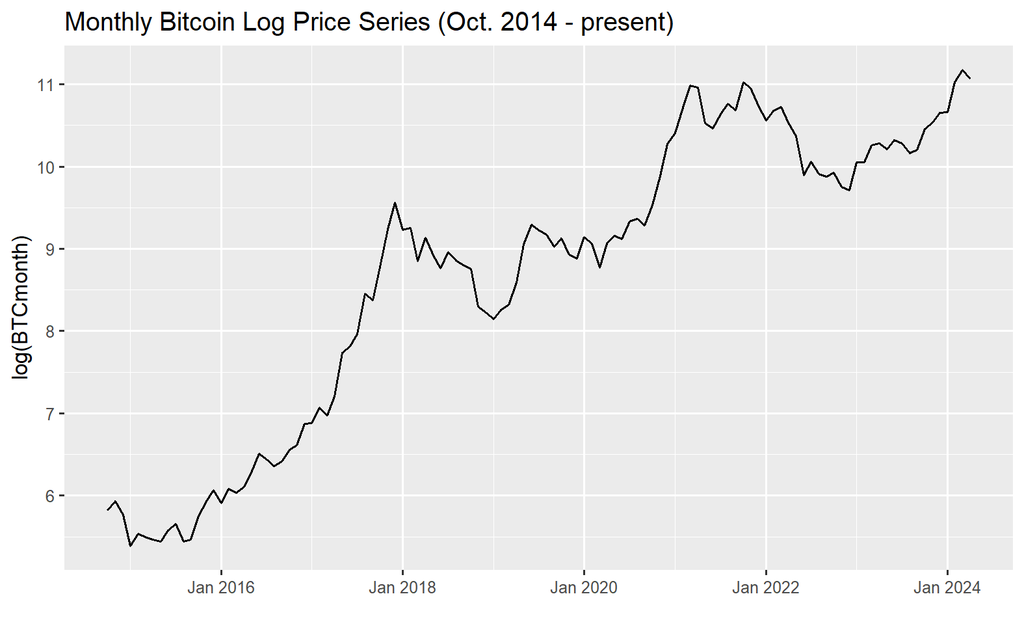

```r
ggplot() +
  geom_line(aes(x=index(BTCmonth), y=log(BTCmonth))) +
  xlab("") +
  ggtitle("Monthly Bitcoin Log Price Series (Oct. 2014 - present)")
```

Alternatively, we can generate the same charts by instead plotting the non-logged price series with a logarithmic y-axis. This is done in `ggplot` with the `scale_y_continuous(transform='log10')` setting.

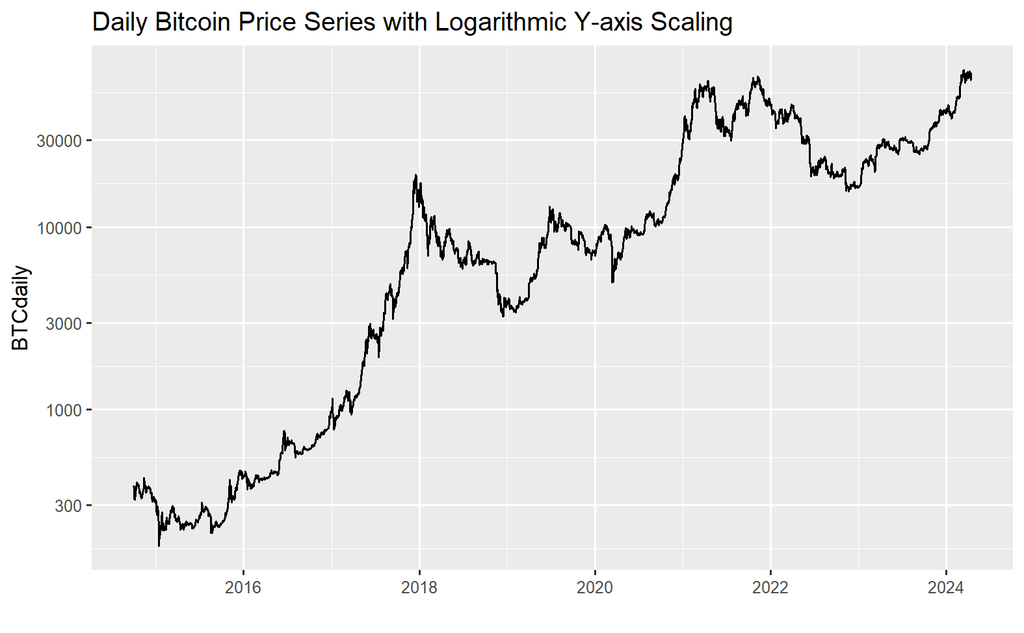

```r
ggplot() +
  geom_line(aes(x=index(BTCdaily), y=BTCdaily)) +
  scale_y_continuous(transform='log10') +
  xlab("") +
  ggtitle("Daily Bitcoin Price Series with Logarithmic Y-axis Scaling")
```

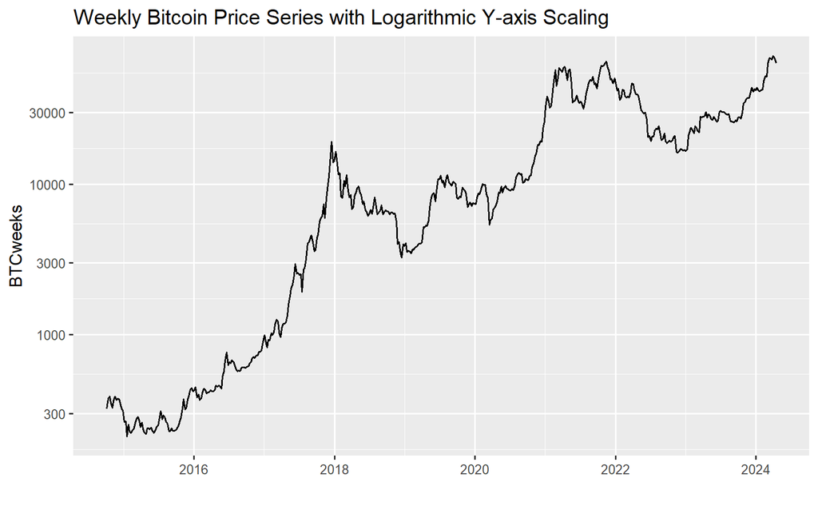

```r
ggplot() +
  geom_line(aes(x=index(BTCweeks), y=BTCweeks)) +
  scale_y_continuous(transform='log10') +
  xlab("") +
  ggtitle("Weekly Bitcoin Price Series with Logarithmic Y-axis Scaling")
```

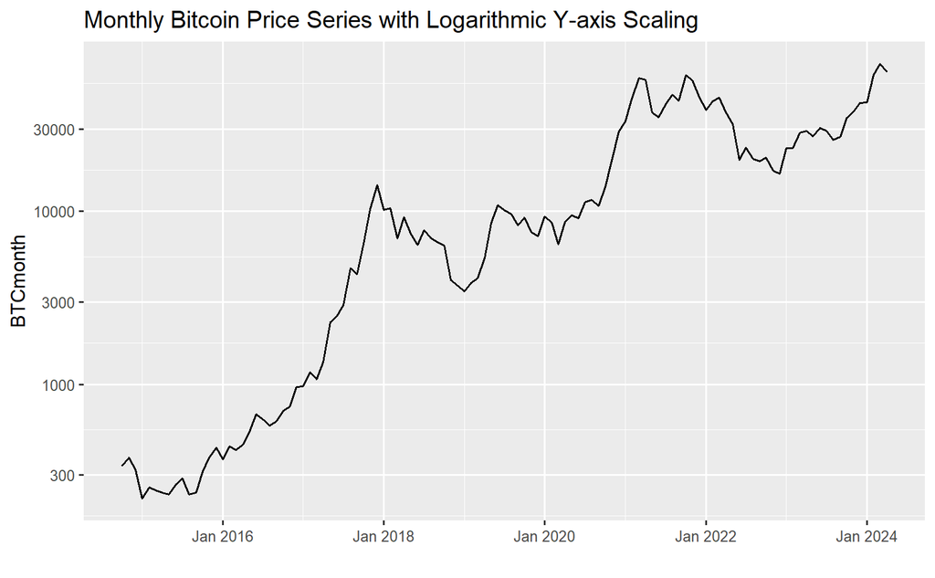

```r
ggplot() +
  geom_line(aes(x=index(BTCmonth), y=BTCmonth)) +
  scale_y_continuous(transform='log10') +
  xlab("") +
  ggtitle("Monthly Bitcoin Price Series with Logarithmic Y-axis Scaling")
```

### Log Return Charts

Lastly, we’ll finish the price to return conversion by differencing the log prices. This can be done directly by composing the `diff()` and `log()` functions. The `log()` function will take the natural logarithm of the prices, and then the `diff()` function will subtract the previous period’s value from the current period’s value. Then to make the series more comparable, we’ll annualize the returns by multiplying by 365 (for daily), 52 (for weekly), and 12 (for monthly). Lastly, we’ll adjust the units to percentages and delete the first observations of each since those are `NA` due to the differencing.

```r
# Create data frames with date column
rBTCdaily = data.frame(Date=index(BTCdaily))
rBTCweeks = data.frame(Date=index(BTCweeks))
rBTCmonth = data.frame(Date=index(BTCmonth))
# Compute log returns
rBTCdaily$Return = diff(log(BTCdaily))
rBTCweeks$Return = diff(log(BTCweeks))
rBTCmonth$Return = diff(log(BTCmonth))
# Annualize returns and shift units to percentages
rBTCdaily$AnnRet = rBTCdaily$Return*100*365
rBTCweeks$AnnRet = rBTCweeks$Return*100*52
rBTCmonth$AnnRet = rBTCmonth$Return*100*12
# Remove first row of each data frame (missing due to differencing)
rBTCdaily = rBTCdaily[-1,]
rBTCweeks = rBTCweeks[-1,]
rBTCmonth = rBTCmonth[-1,]
```

With these return series, we resolve much of the non-stationarity present in the price series. With a more stationary process like returns, a better way to plot the data is with a bar chart. The average bar height (red dashed line) represents the average annual return.

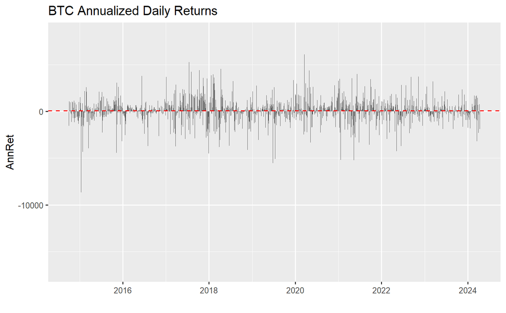

```r
ggplot(rBTCdaily,aes(x=Date,y=AnnRet))+
  geom_col()+
  geom_hline(yintercept=mean(rBTCdaily$AnnRet), linetype='dashed', col='red')+
  xlab("") +
  ggtitle("BTC Annualized Daily Returns")
```

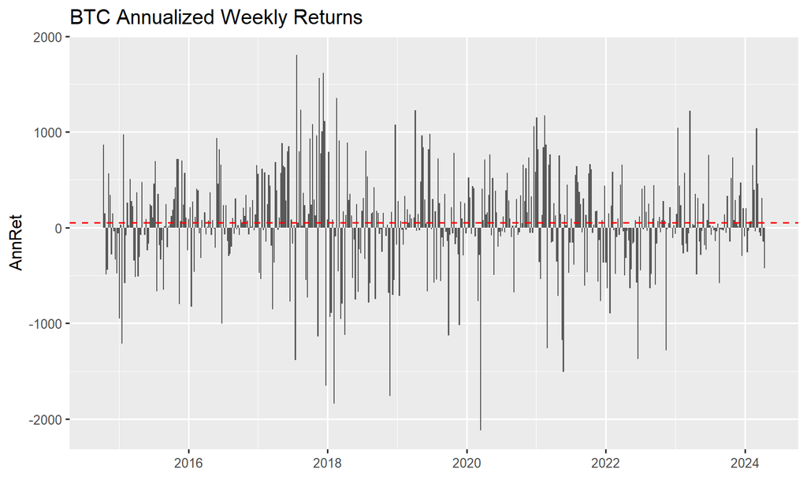

```r
ggplot(rBTCweeks,aes(x=Date,y=AnnRet))+
  geom_col()+
  geom_hline(yintercept=mean(rBTCdaily$AnnRet), linetype='dashed', col='red')+
  xlab("") +
  ggtitle("BTC Annualized Weekly Returns")
```

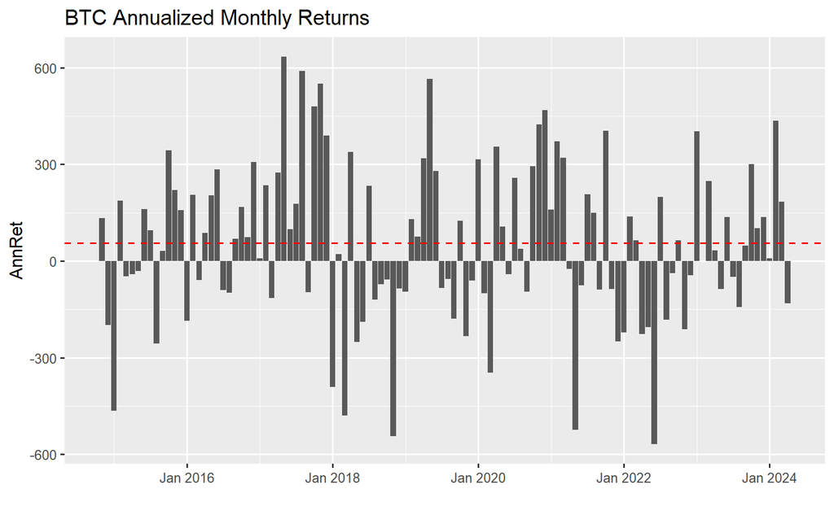

```r
ggplot(rBTCmonth,aes(x=Date,y=AnnRet))+
  geom_col()+
  geom_hline(yintercept=mean(rBTCmonth$AnnRet), linetype='dashed', col='red')+
  xlab("") +
  ggtitle("BTC Annualized Monthly Returns")
```

### Summary Statistics

In summarizing the return series, we can compare across the various frequencies. Since we annualized each series for their respective frequencies, the means of each series represent the average annual returns.

```r
meanAnnRets = data.frame(BTCdaily=mean(rBTCdaily$AnnRet),
                         BTCweeks=mean(rBTCweeks$AnnRet),
                         BTCmonth=mean(rBTCmonth$AnnRet))
meanAnnRets |> round(digits=2)
```

| BTCdaily | BTCweeks | BTCmonth |
| --- | --- | --- |
| 53.61 | 55.41 | 55.17 |

However, from the volatilities (as measured by standard deviation of the return series), we can see that the higher frequencies produce larger standard deviations.

```r
meanRetVols = data.frame(BTCdaily=sd(rBTCdaily$AnnRet),
                         BTCweeks=sd(rBTCweeks$AnnRet),
                         BTCmonth=sd(rBTCmonth$AnnRet))
meanRetVols |> round(digits=2)
```

| BTCdaily | BTCweeks | BTCmonth |
| --- | --- | --- |
| 1353.75 | 513.46 | 247.24 |

One way to visualize the empirical distribution summarized by the mean and standard deviation is to plot a frequency histogram of the return series overlayed with a normal bell curve transformed by the empirical mean and standard deviation. The below code chunk first selects a reasonable bin width (`bw`) for each frequency (trial and error), then saves a count of non-missing observations, and generates the plot described above.

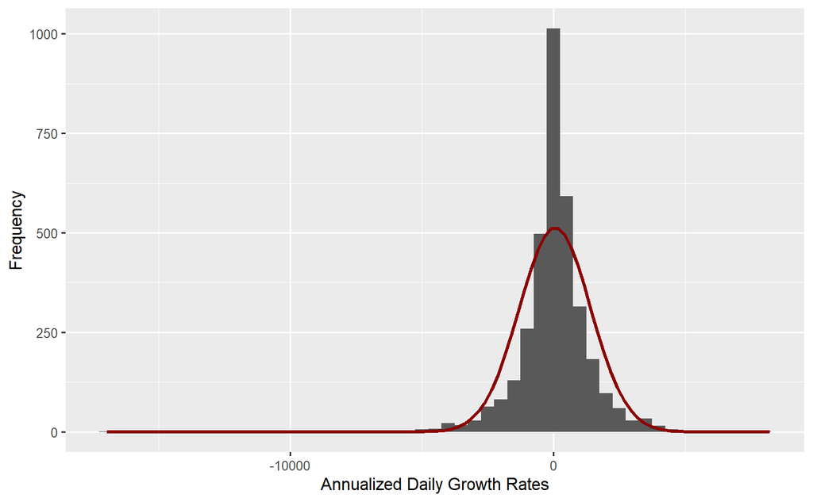

```r
# Set desired binwidth and number of non-missing obs
bw = 500
n_daily = nrow(rBTCdaily)
# Plot histogram of annualized returns and overlay graph of normal bell curve with same means and standard deviation
ggplot(rBTCdaily,aes(AnnRet)) +
  geom_histogram(binwidth=bw) +
  stat_function(fun=function(x) dnorm(x, mean=mean(rBTCdaily$AnnRet),
                                      sd=sd(rBTCdaily$AnnRet))*n_daily*bw,
                color="darkred", linewidth=1) +
  xlab("Annualized Daily Growth Rates") +
  ylab("Frequency")
```

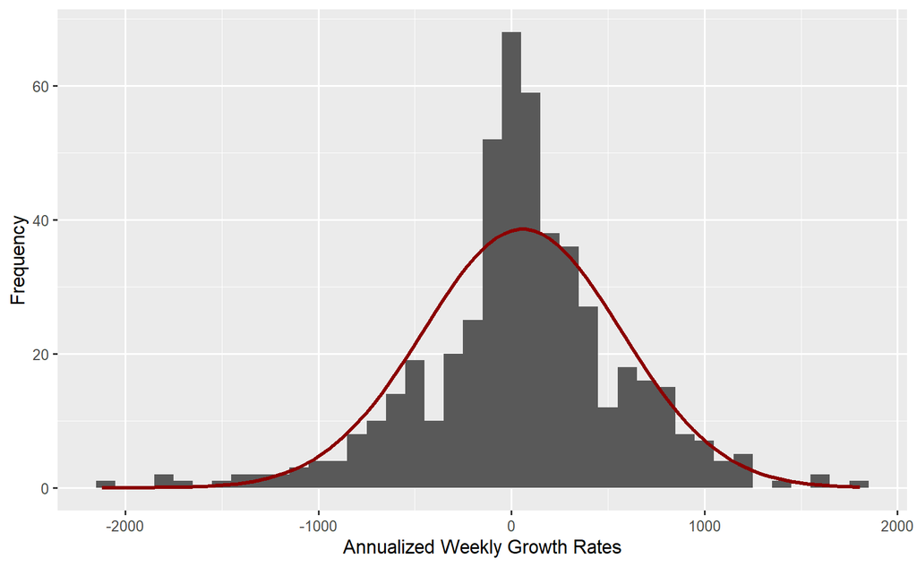

```r
bw = 100
n_weeks = nrow(rBTCweeks)
ggplot(rBTCweeks,aes(AnnRet)) +
  geom_histogram(binwidth=bw) +
  stat_function(fun=function(x) dnorm(x, mean=mean(rBTCweeks$AnnRet),
                                      sd=sd(rBTCweeks$AnnRet))*n_weeks*bw,
                color="darkred", linewidth=1) +
  xlab("Annualized Weekly Growth Rates") +
  ylab("Frequency")
```

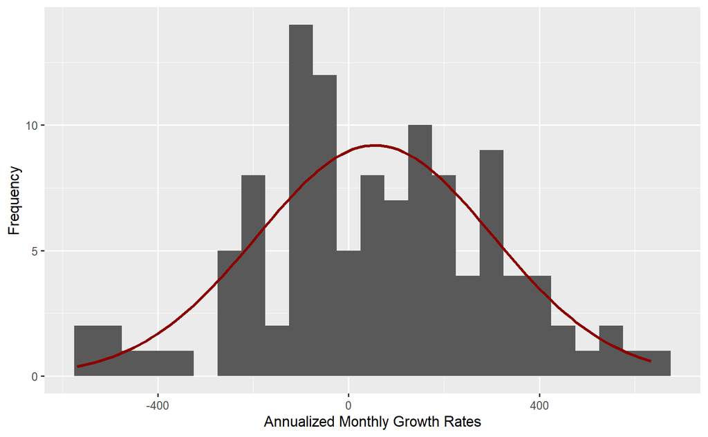

```r
bw = 50
n_month = nrow(rBTCmonth)
ggplot(rBTCmonth,aes(AnnRet)) +
  geom_histogram(binwidth=bw) +
  stat_function(fun=function(x) dnorm(x, mean=mean(rBTCmonth$AnnRet),
                                      sd=sd(rBTCmonth$AnnRet,))*n_month*bw,
                color="darkred", linewidth=1) +
  xlab("Annualized Monthly Growth Rates") +
  ylab("Frequency")
```

## Time Series Stationarity, Autocorrelation, and the Dickey-Fuller Test

A [Stationary](https://en.wikipedia.org/wiki/Stationary_process) [Process](https://www.itl.nist.gov/div898/handbook/pmc/section4/pmc442.htm) is one that has a constant mean, variance, and autocorrelation structure over time. A [Non-Stationary Process](https://www.investopedia.com/articles/trading/07/stationary.asp) can have different aspects of non-stationarity, and financial variables often exhibit those types of trends. As we could visually see from the price and return plots, the prices had a clear upward trend over the long-run, whereas the return series exhibited ‘flatter’ dynamics. A more explicit way to visualize the autocorrelation structure of the time series is to examine its [autocorrelation function (ACF)](https://www.itl.nist.gov/div898/handbook/eda/section3/autocopl.htm). The ACF effectively measures the correlation between $e_t$ and $e_{t−1}$, and then for $e_t$ and $e_{t−2}$, and so on for as many lags as desired. In each frequency, the price series exhibits substantial autocorrelation, and the return series shows that much of it is resolved, although there still are a few lags that exceed the error bands.

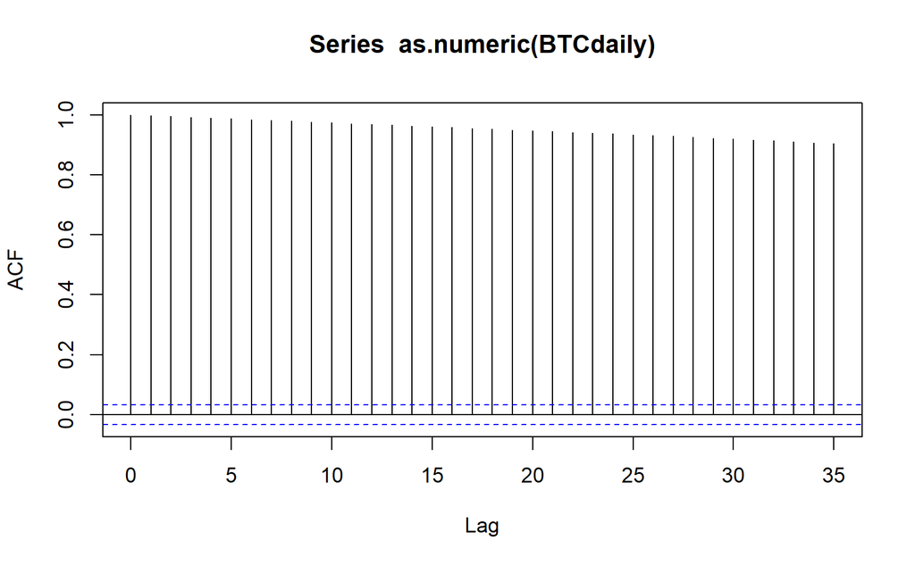

```r
acf(as.numeric(BTCdaily))
```

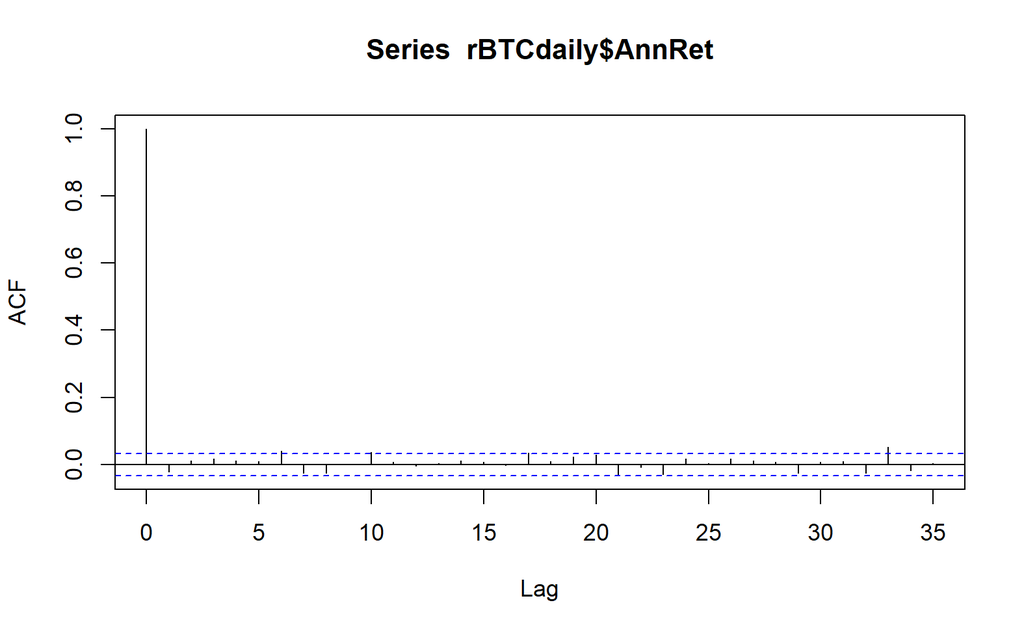

```r
acf(rBTCdaily$AnnRet)
```

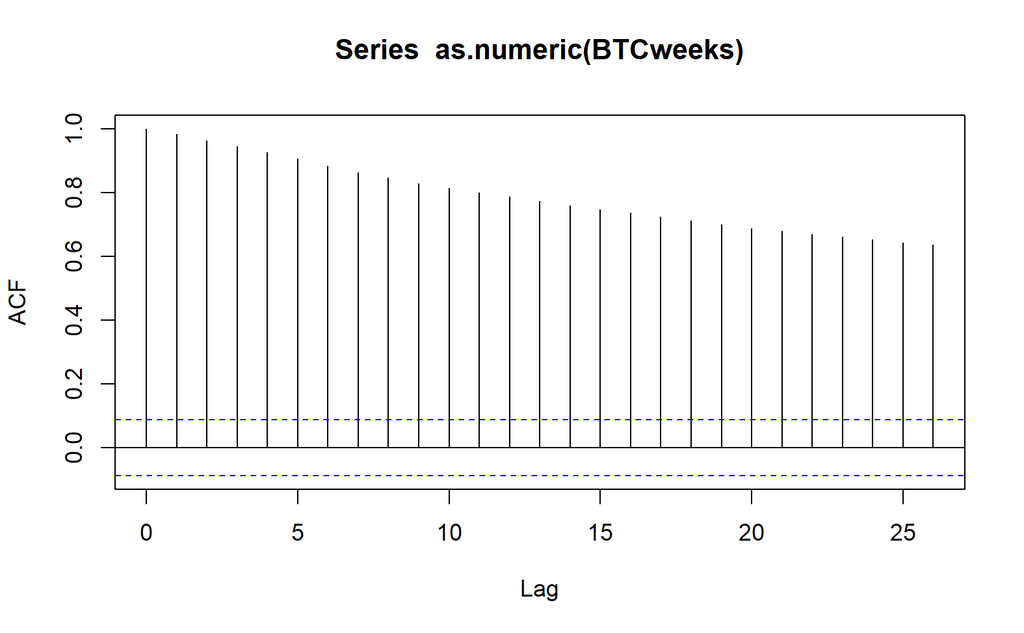

```r
acf(as.numeric(BTCweeks))
```

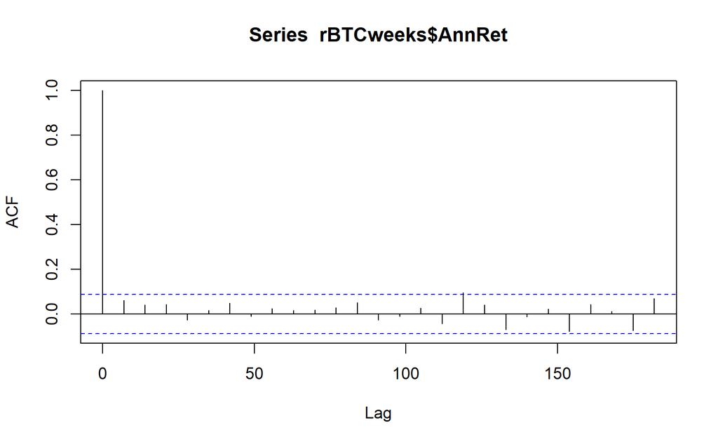

```r
acf(rBTCweeks$AnnRet)
```

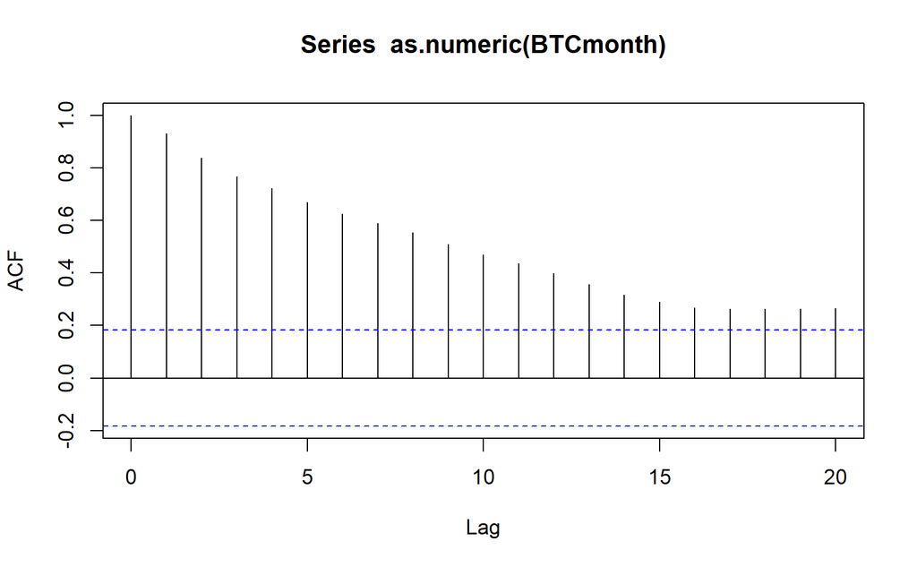

```r
acf(as.numeric(BTCmonth))
```

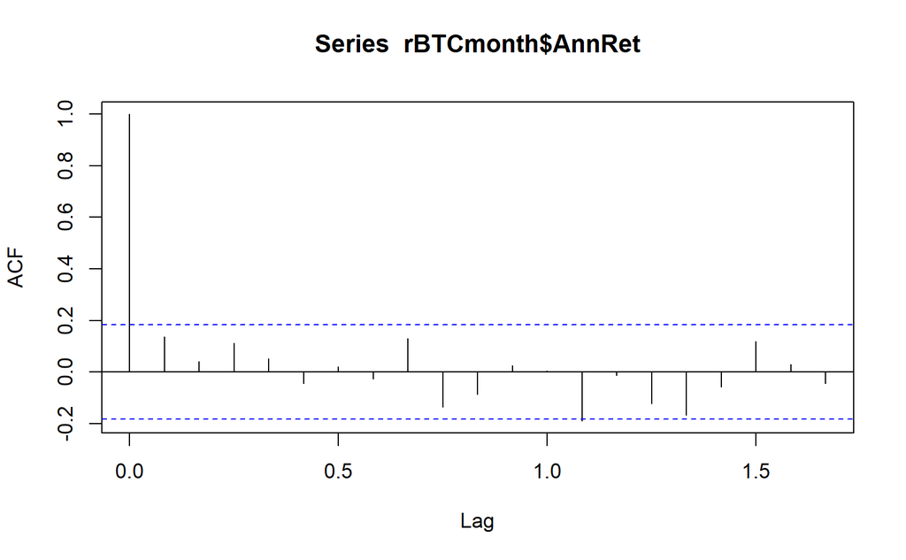

```r
acf(rBTCmonth$AnnRet)
```

The [partial autocorrelation function (PACF)](https://www.itl.nist.gov/div898/handbook/pmc/section4/pmc4463.htm) is similar to the ACF, except it produces the estimates of each lag after controlling for all shorter lags. In other words, rather than measuring the correlation between $e_t$ and $e_{t−2}$, we’d measure the linear regression coefficient for the second lag from a regression including both the first and second lags. A notable feature here from the price series is a very large (nearly 1) estimate, which follows from the large autocorrelation. Then subsequent lags often fall within the error bands, although some lags do exceed them. After converting to returns, the PACF’s have a much more condensed y-axis, which reflects the lower autocorrelation in the return series. Although, there certainly are still some lags that cross the error bands for the daily and weekly series.

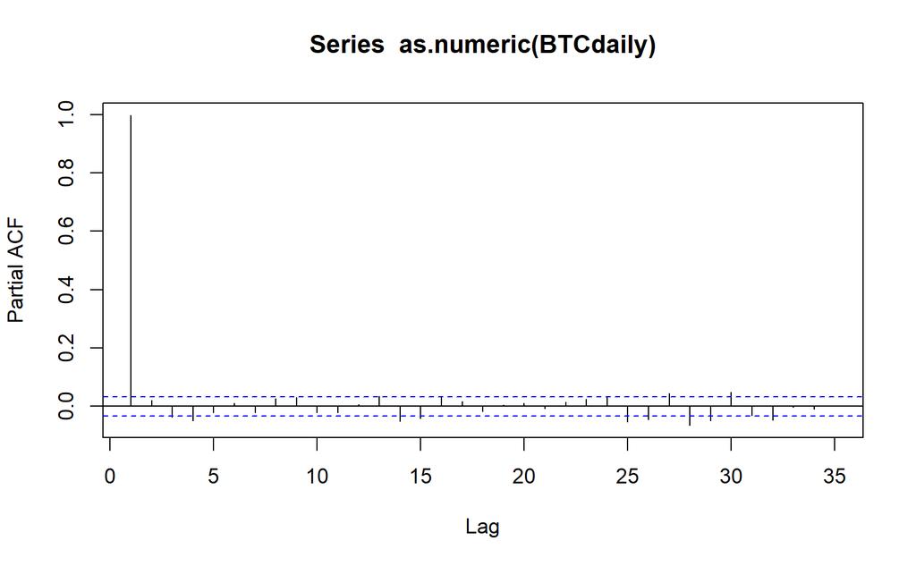

```r
pacf(as.numeric(BTCdaily))
```

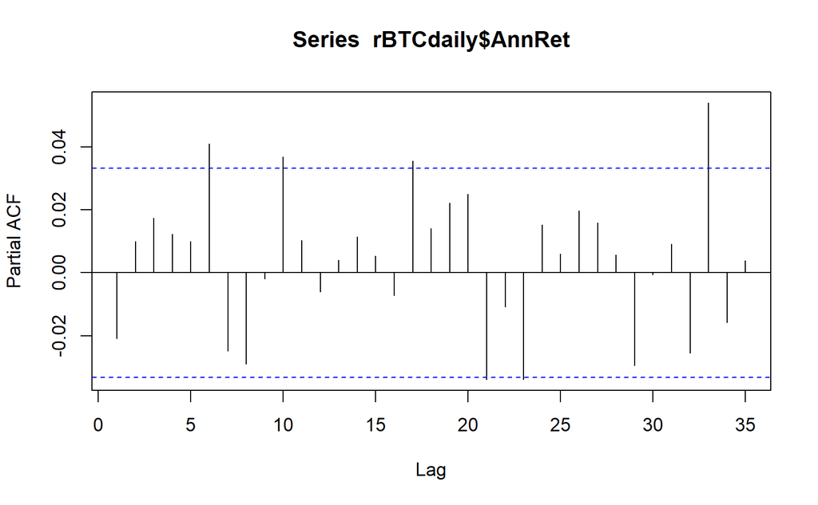

```r
pacf(rBTCdaily$AnnRet)
```

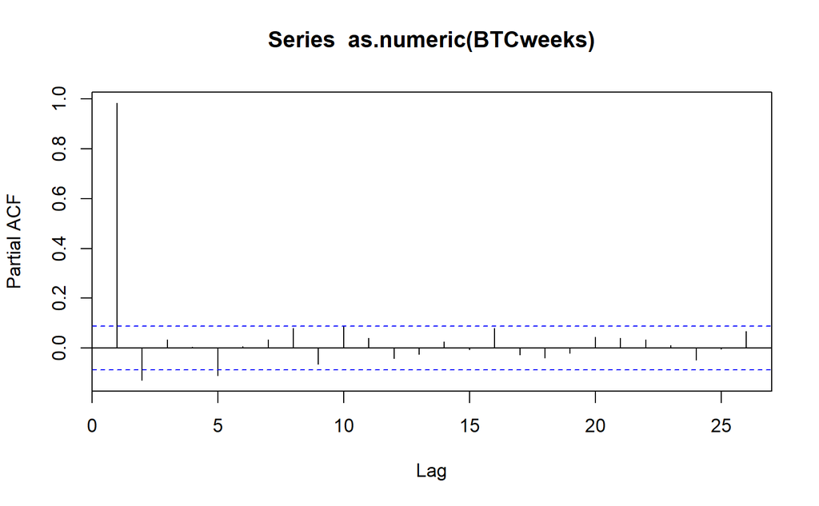

```r
pacf(as.numeric(BTCweeks))
```

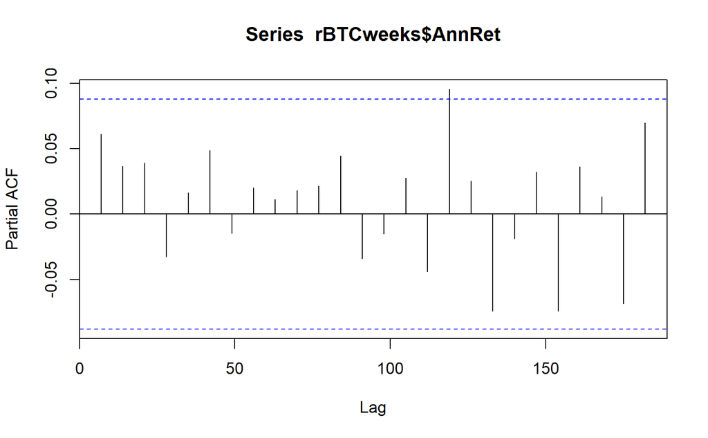

```r
pacf(rBTCweeks$AnnRet)
```

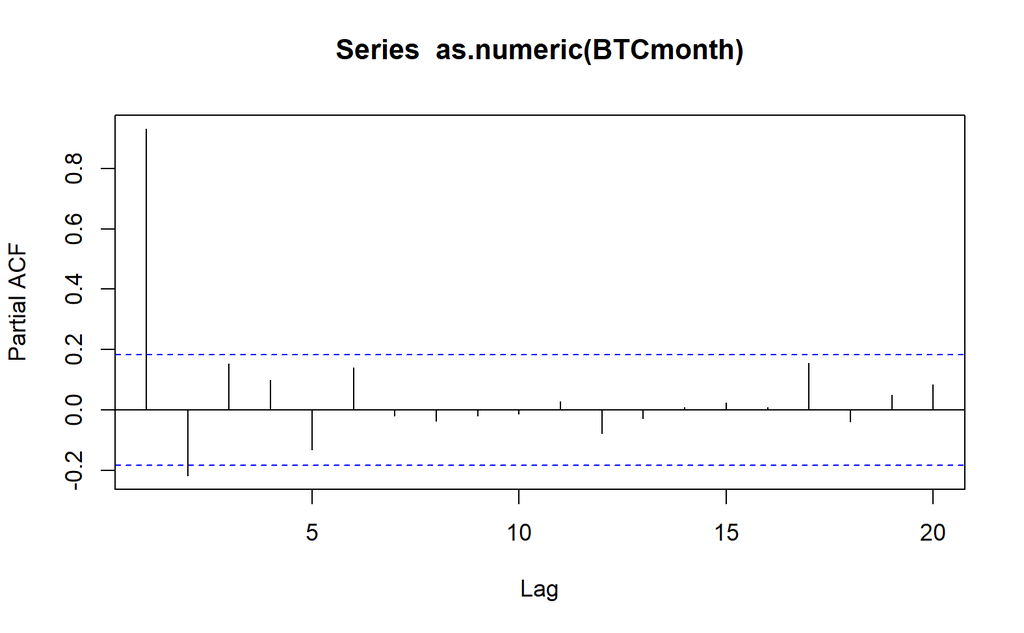

```r
pacf(as.numeric(BTCmonth))
```

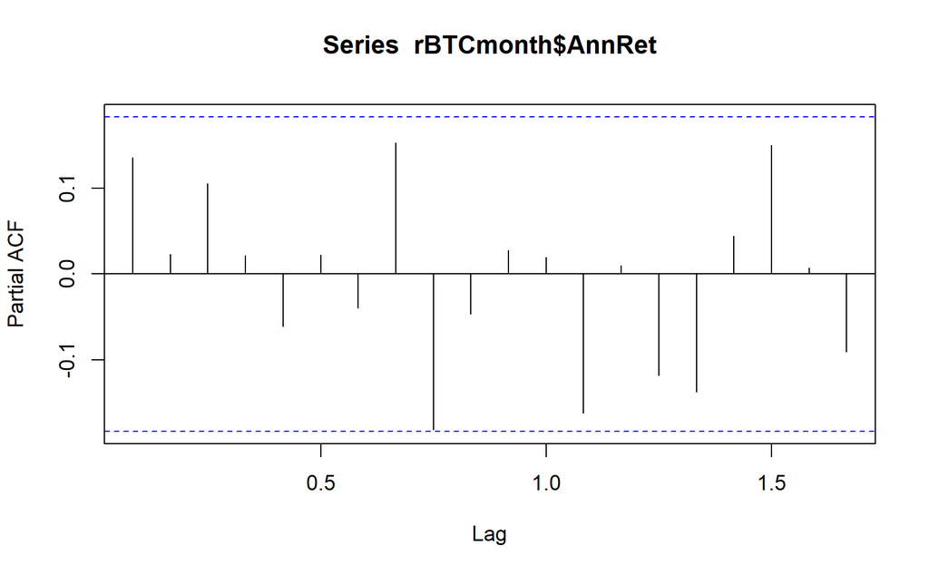

```r
pacf(rBTCmonth$AnnRet)
```

From the ACF and PACF, we can gather some visual evidence to support the suggestion that the price series suffers from autocorrelation (non-stationarity) and that the return series is stationary. To explicitly test for this, the [Augmented](https://en.wikipedia.org/wiki/Augmented_Dickey%E2%80%93Fuller_test) [Dickey-Fuller](https://www.rdocumentation.org/packages/aTSA/versions/3.1.2/topics/adf.test) [Test](https://cran.r-project.org/web/packages/tseries/tseries.pdf) allows us to construct a null hypothesis of non-stationarity, which implies that rejection of the null concludes stationarity. The `adf.test()` function comes from the `tseries` R package and generates the test statistic (Dickey-Fuller in the output) and p-value. We can see that the price series have smaller (in magnitude) test statistics that fail to reject the null, and then the return series produce larger (in magnitude) test statistics that reject the null and conclude that the return series are a stationary process.

```r
adf.test(as.numeric(BTCdaily))
```

```
    Augmented Dickey-Fuller Test

data:  as.numeric(BTCdaily)
Dickey-Fuller = -1.9961, Lag order = 15, p-value = 0.58
alternative hypothesis: stationary
```

```r
adf.test(rBTCdaily$AnnRet)
```

```
    Augmented Dickey-Fuller Test

data:  rBTCdaily$AnnRet
Dickey-Fuller = -14.14, Lag order = 15, p-value = 0.01
alternative hypothesis: stationary
```

```r
adf.test(as.numeric(BTCweeks))
```

```
    Augmented Dickey-Fuller Test

data:  as.numeric(BTCweeks)
Dickey-Fuller = -2.591, Lag order = 7, p-value = 0.3282
alternative hypothesis: stationary
```

```r
adf.test(rBTCweeks$AnnRet)
```

```
    Augmented Dickey-Fuller Test

data:  rBTCweeks$AnnRet
Dickey-Fuller = -7.2019, Lag order = 7, p-value = 0.01
alternative hypothesis: stationary
```

```r
adf.test(as.numeric(BTCmonth))
```

```
    Augmented Dickey-Fuller Test

data:  as.numeric(BTCmonth)
Dickey-Fuller = -2.623, Lag order = 4, p-value = 0.318
alternative hypothesis: stationary
```

```r
adf.test(rBTCmonth$AnnRet)
```

```
    Augmented Dickey-Fuller Test

data:  rBTCmonth$AnnRet
Dickey-Fuller = -4.3493, Lag order = 4, p-value = 0.01
alternative hypothesis: stationary
```

If you want to dig deeper into the theory and underlying assumptions behind these concepts, [Stationarity and Memory in Financial Markets](https://towardsdatascience.com/non-stationarity-and-memory-in-financial-markets-fcef1fe76053) has a nice discussion on the topic from a general context of financial markets.

## Seasonality

### Day-of-Week Seasonality

Another area of concern when it comes to stationarity of a time series is seasonality. For the time series that we have here, the first type of ‘season’ to check is day of the week for the daily series. One way to do this is to generate a count variable ($count=1,2,...,T$), and then calculate the remainder after dividing by 7. This [modulo operation](https://en.wikipedia.org/wiki/Modulo_operation) is done with `%%` in R. Then a quick test for seasonality is to regress the return series on a factor variable of the remainders. The `as.factor()` function will transform the numeric variable into a categorical variable with 7 categories.

Thus, after increasing the count, the most negative day will be the baseline, and all the day dummies should produce a positive coefficient. This shift will maximize the likelihood that we find a significant result from the regression by comparing each other day to one of the extremes.

```r
rBTCdaily$count = 1:length(rBTCdaily$AnnRet)
rBTCdaily$day = (rBTCdaily$count+6) %% 7
weekreg = lm(AnnRet~as.factor(day),data=rBTCdaily)
summary(weekreg)
```

```
Call:
lm(formula = AnnRet ~ as.factor(day), data = rBTCdaily)

Residuals:
     Min       1Q   Median       3Q      Max
-16956.8   -509.8      1.4    565.6   8222.7

Coefficients:
                Estimate Std. Error t value Pr(>|t|)
(Intercept)       -5.889     60.667  -0.097   0.9227
as.factor(day)1   67.755     85.795   0.790   0.4297
as.factor(day)2   61.120     85.795   0.712   0.4763
as.factor(day)3   26.486     85.795   0.309   0.7576
as.factor(day)4  174.952     85.839   2.038   0.0416 *
as.factor(day)5   11.785     85.839   0.137   0.8908
as.factor(day)6   74.578     85.839   0.869   0.3850
---
Signif. codes:  0 ‘***’ 0.001 ‘**’ 0.01 ‘*’ 0.05 ‘.’ 0.1 ‘ ’ 1

Residual standard error: 1354 on 3476 degrees of freedom
Multiple R-squared:  0.0016,    Adjusted R-squared:  -0.0001233
F-statistic: 0.9284 on 6 and 3476 DF,  p-value: 0.4731
```

In addition to testing for seasonality, we can also include the count variable as a linear time trend to see if returns are systematically changing over time. As seen below, this loads slightly negative and very insignificant.

```r
weekreg2 = lm(AnnRet~count+as.factor(day),data=rBTCdaily)
summary(weekreg2)
```

```
Call:
lm(formula = AnnRet ~ count + as.factor(day), data = rBTCdaily)

Residuals:
     Min       1Q   Median       3Q      Max
-16955.4   -508.5      0.9    565.2   8219.6

Coefficients:
                 Estimate Std. Error t value Pr(>|t|)
(Intercept)       3.42347   72.51714   0.047   0.9623
count            -0.00535    0.02282  -0.234   0.8146
as.factor(day)1  67.76019   85.80713   0.790   0.4298
as.factor(day)2  61.13046   85.80714   0.712   0.4763
as.factor(day)3  26.50227   85.80715   0.309   0.7574
as.factor(day)4 174.95499   85.85028   2.038   0.0416 *
as.factor(day)5  11.79284   85.85028   0.137   0.8908
as.factor(day)6  74.59119   85.85030   0.869   0.3850
---
Signif. codes:  0 ‘***’ 0.001 ‘**’ 0.01 ‘*’ 0.05 ‘.’ 0.1 ‘ ’ 1

Residual standard error: 1354 on 3475 degrees of freedom
Multiple R-squared:  0.001616,  Adjusted R-squared:  -0.0003953
F-statistic: 0.8034 on 7 and 3475 DF,  p-value: 0.5843
```

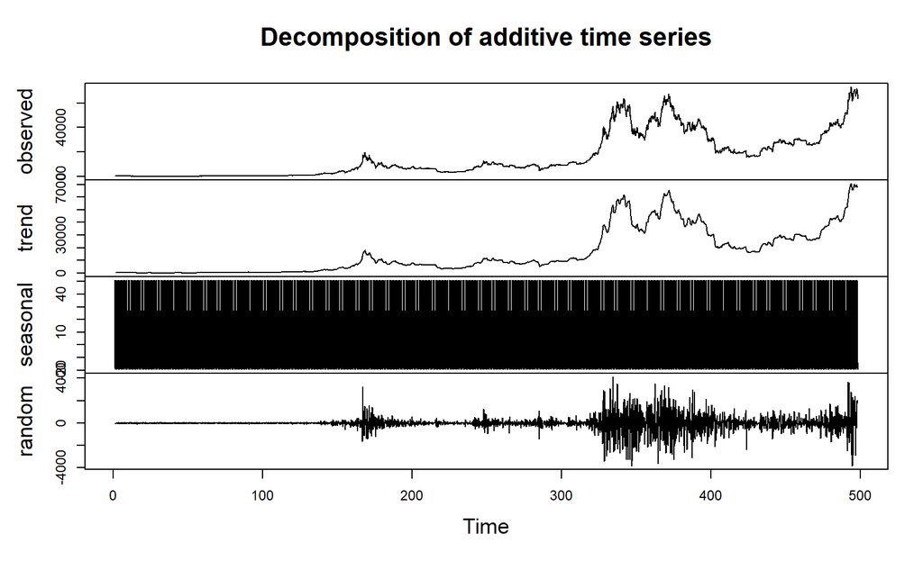

```r
BTCdailyts = ts(as.numeric(BTCdaily), frequency=7)
BTCdailytsdecomp = decompose(BTCdailyts)
plot(BTCdailytsdecomp)
```

### Day-of-Year Seasonality

A more common approach to seasonality is to model the time of the year to capture the impact of actual seasons. This can be done with the daily price series; however, since the regression model would output coefficients for all the 364 day dummy variables, we’ll just generate the time series decomposition plot. One additional parameter we can include in this case is indicating the starting point of the data. Since this is an annual cycle, the first numeric input is the starting year, and the 274 is derived from the first observation on October 1, which was the 274th day of year in 2014. *An potential flaw here may be the handling of leap years. I’m not sure that the tseries package is correctly handling leap years when the frequency is set to 365. It is likely just modeling a 365-day cycle, so every leap year will shift the particular dates by 1.*

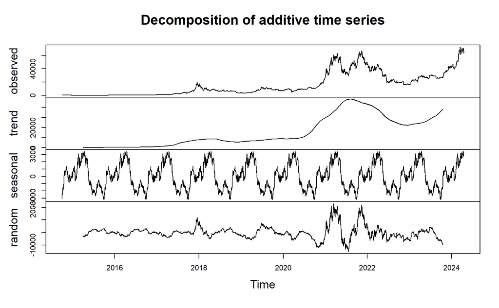

```r
BTCdayyearts = ts(as.numeric(BTCdaily), frequency=365, start=c(2014,274))
BTCdayyeartsdecomp = decompose(BTCdayyearts)
plot(BTCdayyeartsdecomp)
```

### Month-of-Year Seasonality

The next level to test for seasonality at is for each month of the year. Similar to above, we create a count in the monthly data frame, calculate $count \mod 12$ with a 1-month shift (to adjust the baseline to the worst month), and then regress the returns on a factor variable of the remainders.

```r
rBTCmonth$count = 1:length(rBTCmonth$AnnRet)
rBTCmonth$month = (rBTCmonth$count+1) %% 12
monthreg = lm(AnnRet~as.factor(month),data=rBTCmonth)
summary(monthreg)
```

```
Call:
lm(formula = AnnRet ~ as.factor(month), data = rBTCmonth)

Residuals:
   Min     1Q Median     3Q    Max
-585.9 -141.2  -10.5  145.6  599.2

Coefficients:
                   Estimate Std. Error t value Pr(>|t|)
(Intercept)        -47.0790    81.8175  -0.575   0.5663
as.factor(month)1  282.6782   115.7075   2.443   0.0163 *
as.factor(month)2   89.6428   112.7777   0.795   0.4285
as.factor(month)3  129.2708   112.7777   1.146   0.2544
as.factor(month)4    0.6077   112.7777   0.005   0.9957
as.factor(month)5  209.5082   112.7777   1.858   0.0661 .
as.factor(month)6   31.2896   112.7777   0.277   0.7820
as.factor(month)7  145.5491   112.7777   1.291   0.1998
as.factor(month)8   92.9380   115.7075   0.803   0.4237
as.factor(month)9   56.0997   115.7075   0.485   0.6288
as.factor(month)10 151.8878   115.7075   1.313   0.1922
as.factor(month)11  38.4237   115.7075   0.332   0.7405
---
Signif. codes:  0 ‘***’ 0.001 ‘**’ 0.01 ‘*’ 0.05 ‘.’ 0.1 ‘ ’ 1

Residual standard error: 245.5 on 102 degrees of freedom
Multiple R-squared:  0.1103,    Adjusted R-squared:  0.01441
F-statistic:  1.15 on 11 and 102 DF,  p-value: 0.3313
```

Similar to the daily series, the linear time trend of the monthly series is not statistically significant.

```r
monthreg2 = lm(AnnRet~count+as.factor(month),data=rBTCmonth[rBTCmonth$Date!=as.yearmon("Nov 2013"),])
summary(monthreg2)
```

```
Call:
lm(formula = AnnRet ~ count + as.factor(month), data = rBTCmonth[rBTCmonth$Date !=
    as.yearmon("Nov 2013"), ])

Residuals:
    Min      1Q  Median      3Q     Max
-587.69 -145.89  -19.17  140.11  591.85

Coefficients:
                     Estimate Std. Error t value Pr(>|t|)
(Intercept)        -29.033927  92.003990  -0.316   0.7530
count               -0.305848   0.702321  -0.435   0.6641
as.factor(month)1  282.984059 116.171969   2.436   0.0166 *
as.factor(month)2   88.419431 113.263204   0.781   0.4368
as.factor(month)3  128.353219 113.247961   1.133   0.2597
as.factor(month)4   -0.003985 113.237072   0.000   1.0000
as.factor(month)5  209.202383 113.230538   1.848   0.0676 .
as.factor(month)6   31.289588 113.228359   0.276   0.7829
as.factor(month)7  145.854992 113.230538   1.288   0.2006
as.factor(month)8   91.714612 116.203809   0.789   0.4318
as.factor(month)9   55.182203 116.188951   0.475   0.6359
as.factor(month)10 151.276065 116.178337   1.302   0.1958
as.factor(month)11  38.117843 116.171969   0.328   0.7435
---
Signif. codes:  0 ‘***’ 0.001 ‘**’ 0.01 ‘*’ 0.05 ‘.’ 0.1 ‘ ’ 1

Residual standard error: 246.4 on 101 degrees of freedom
Multiple R-squared:  0.112, Adjusted R-squared:  0.006512
F-statistic: 1.062 on 12 and 101 DF,  p-value: 0.4003
```

Now let’s plot out the full time series decomposition of the monthly series. Since this is one of the more meaningful decompositions we’ll generate, the final three lines below will create a high-quality output of the plot in a pdf format.

```r
BTCts_Close = ts(as.numeric(BTCmonth), frequency=12, start=c(2014,10))
BTCtsdecomp = decompose(BTCts_Close)
plot(BTCtsdecomp)
# Create output pdf file for the plot, plot it, and save file.
pdf("BTCtsdecomp_month_year.pdf", width=6)
```

[output not shown]

```r
plot(BTCtsdecomp)
dev.off()
```

### Bitcoin Halving Seasonality

One feature of the Bitcoin protocol is the reduction in block rewards that occurs every four years. Specifically, this fixed portion of mining rewards that are new bitcoins being mined into existence get reduced by 50% every 210,000 blocks. Since the mining process produces a new block every 10 minutes, this translates to roughly 4 years.

$1 halving = 210,000 blocks \cdot \dfrac{10min}{1block} \cdot \dfrac{1hr}{60min} \cdot \dfrac{1day}{24hr} = 1,458days+8hr = 208.\overline{33}weeks = 3.995years$

In addition to not exactly measuring 4 years, there is the additional variation around the 10 minute-per-block timing in the short-term. The Bitcoin protocol has a difficulty adjustment that takes effect every 2,016 blocks ($$14 days). This automatic adjustment allows the mining difficulty to adapt to changes in network hash rate without impacting the block timing, which enables Bitcoin’s algorithmic monetary inflation.

So there isn’t quite a clean way to split the halving timeline into perfect cycles at any of the frequencies. But we can round to the nearest whole number and see what we get with each.

#### Daily Halving Seasonality

The Bitcoin halving cycle is closest to 1,458 days, so lets examine the time series decomposition with that frequency. Since the decomposition charts transform the date component to cycle-time, the points below transform the halving dates to the corresponding time values on the chart.

- 2012 Halving (Nov. 28, block 210,000): No price data yet
- 2016 Halving (July 9, block 420,000): `dayhalf`=647 $\implies$ Time=1.44
- 2020 Halving (May 11, block 630,000): `dayhalf`=591 $\implies$ Time=2.41
- 2024 Halving (April 20, block 840,000): `dayhalf`=573 $\implies$ Time=3.39
- 2028 Halving (March?, block 1,050,000): `dayhalf`=??? $\implies$ Time=4.??

Since we just added 1,457 dummy variables to the regression model, it is not surprising that absorbed much of the volatility. This is also why we don’t display the summary of the results. Then the lack of three full cycles leads to a flat period in the residual (random). This is expected since some of the estimates are based on only two observations. As time moves on and more halvings are experienced, any seasonality around this cycle should become more apparent.

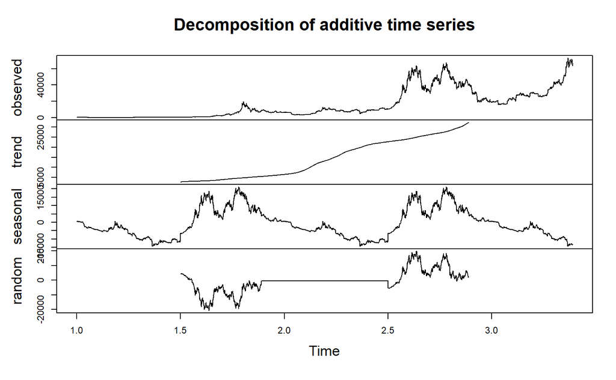

```r
rBTCdaily$dayhalf = rBTCdaily$count %% 1458
dailyhalfreg = lm(AnnRet~count+as.factor(dayhalf),data=rBTCdaily)
BTCdailyhalfts = ts(as.numeric(BTCdaily), frequency=1458)
BTCdailyhalftsdecomp = decompose(BTCdailyhalfts)
plot(BTCdailyhalftsdecomp)
```

#### Weekly Halving Seasonality

Similarly, we can modeling this halving seasonality at the weekly frequency. The halving cycle is closest to 208 weeks, so we’ll use that as the frequency for the time series decomposition. Overall, we see similar trends as with the daily data. Similar to the daily decomposition chart, the dates are transformed to cycle-time. So the points below transform the halving dates to the corresponding time values on the chart.

- 2012 Halving (Nov. 28, block 210,000): No price data yet
- 2016 Halving (July 9, block 420,000): `weekhalf`=92 $\implies$ Time=1.44
- 2020 Halving (May 11, block 630,000): `weekhalf`=85 $\implies$ Time=2.41
- 2024 Halving (April 20, block 840,000): `weekhalf`=82 $\implies$ Time=3.39
- 2028 Halving (March?, block 1,050,000): `weekhalf`=??? $\implies$ Time=4.??

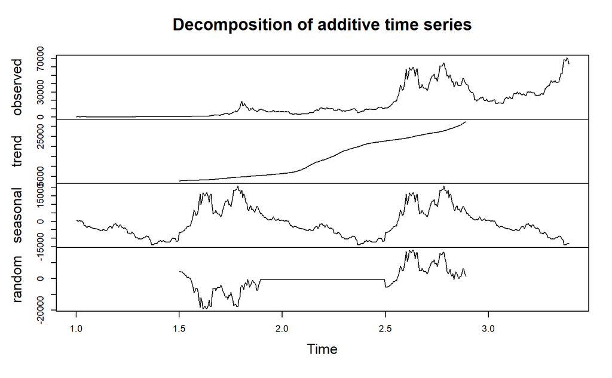

```r
rBTCweeks$count = 1:length(rBTCweeks$AnnRet)
rBTCweeks$weekhalf = rBTCweeks$count %% 208
weekshalfreg = lm(AnnRet~count+as.factor(weekhalf),data=rBTCweeks)
BTCweekshalfts = ts(as.numeric(BTCweeks), frequency=208)
BTCweekshalftsdecomp = decompose(BTCweekshalfts)
plot(BTCweekshalftsdecomp)
```

#### Monthly Halving Seasonality

Since the monthly halving cycle is only 48 months, let’s also generate the regression estimates to check for some significant months in a halving cycle. As with the other frequencies, the points below transform the halving dates to cycle-time. Then let’s also save this plot as a pdf.

- 2012 Halving (Nov. 28, block 210,000): No price data yet
- 2016 Halving (July 9, block 420,000): `monthhalf`=21 $\implies$ Time=1.44
- 2020 Halving (May 11, block 630,000): `monthhalf`=19 $\implies$ Time=2.40
- 2024 Halving (April 20, block 840,000): `monthhalf`=18 $\implies$ Time=3.38
- 2028 Halving (March?, block 1,050,000): `monthhalf`=?? $\implies$ Time=4.??

```r
BTCmonthhalfts = ts(as.numeric(BTCmonth), frequency=48)
BTCmonthhalftsdecomp = decompose(BTCmonthhalfts)
plot(BTCmonthhalftsdecomp)
rBTCmonth$monthhalf = rBTCmonth$count %% 48
monthhalfreg = lm(AnnRet~count+as.factor(monthhalf),data=rBTCmonth)
summary(monthhalfreg)
```

[output not shown]

```
Call:
lm(formula = AnnRet ~ count + as.factor(monthhalf), data = rBTCmonth)

Residuals:
    Min      1Q  Median      3Q     Max
-578.40  -89.64    0.05   82.05  578.40

Coefficients:
                         Estimate Std. Error t value Pr(>|t|)
(Intercept)               4.69361  178.01072   0.026   0.9790
count                    -0.01757    0.70400  -0.025   0.9802
as.factor(monthhalf)1  -211.37430  220.89154  -0.957   0.3422
as.factor(monthhalf)2  -113.30908  220.84105  -0.513   0.6096
as.factor(monthhalf)3   -56.10582  220.79279  -0.254   0.8002
as.factor(monthhalf)4   102.36775  220.74677   0.464   0.6444
as.factor(monthhalf)5    88.22714  220.70299   0.400   0.6906
as.factor(monthhalf)6    99.71984  220.66144   0.452   0.6528
as.factor(monthhalf)7   145.64736  220.62213   0.660   0.5115
as.factor(monthhalf)8   187.85194  220.58506   0.852   0.3976
as.factor(monthhalf)9   -16.88036  220.55023  -0.077   0.9392
as.factor(monthhalf)10 -155.21014  220.51765  -0.704   0.4840
as.factor(monthhalf)11  -37.44984  220.48730  -0.170   0.8657
as.factor(monthhalf)12  252.61664  220.45920   1.146   0.2561
as.factor(monthhalf)13   25.31731  220.43335   0.115   0.9089
as.factor(monthhalf)14   74.40353  220.40974   0.338   0.7368
as.factor(monthhalf)15   42.32744  220.38837   0.192   0.8483
as.factor(monthhalf)16  176.55437  220.36926   0.801   0.4259
as.factor(monthhalf)17  -77.64378  220.35239  -0.352   0.7257
as.factor(monthhalf)18  100.37585  220.33777   0.456   0.6502
as.factor(monthhalf)19  151.23533  242.18564   0.624   0.5345
as.factor(monthhalf)20  117.28768  242.12731   0.484   0.6297
as.factor(monthhalf)21   79.75604  242.07101   0.329   0.7429
as.factor(monthhalf)22  -34.47325  242.01675  -0.142   0.8872
as.factor(monthhalf)23  -17.07101  241.96452  -0.071   0.9440
as.factor(monthhalf)24  226.92463  241.91433   0.938   0.3517
as.factor(monthhalf)25  245.40711  241.86618   1.015   0.3140
as.factor(monthhalf)26  384.39784  241.82007   1.590   0.1168
as.factor(monthhalf)27   79.90161  241.77600   0.330   0.7421
as.factor(monthhalf)28  299.39107  241.73398   1.239   0.2200
as.factor(monthhalf)29   98.40711  241.69399   0.407   0.6852
```

[output cut: 9 more lines]

```
as.factor(monthhalf)39 -310.05116  241.40674  -1.284   0.2036
as.factor(monthhalf)40   75.99907  241.38929   0.315   0.7539
as.factor(monthhalf)41 -211.51418  241.37389  -0.876   0.3841
as.factor(monthhalf)42   52.24942  241.36054   0.216   0.8293
as.factor(monthhalf)43 -231.70017  241.34925  -0.960   0.3406
as.factor(monthhalf)44 -382.40898  241.34001  -1.585   0.1179
as.factor(monthhalf)45  212.40794  241.33282   0.880   0.3820
as.factor(monthhalf)46 -154.76385  241.32768  -0.641   0.5236
as.factor(monthhalf)47  -58.42811  241.32460  -0.242   0.8095
---
Signif. codes:  0 ‘***’ 0.001 ‘**’ 0.01 ‘*’ 0.05 ‘.’ 0.1 ‘ ’ 1

Residual standard error: 241.3 on 65 degrees of freedom
Multiple R-squared:  0.452, Adjusted R-squared:  0.04729
F-statistic: 1.117 on 48 and 65 DF,  p-value: 0.336
```

```r
# Create output pdf file for the plot, plot it, and save file.
pdf("BTCtsdecomp_month_half.pdf", width=6)
```

```r
plot(BTCmonthhalftsdecomp)
dev.off()
```

### A Deeper Dive on Seasonality

So far, we have just used some fairly basic seasonality tools from the tseries package. A more in-depth package focused around seasonal adjustments for time series data is the seasonal package. The `seas()` function will output the main results from the X-13 ARIMA-SEATS seasonal adjustment method. If you wish to explore this model in more detail, uncomment the `view()` function in the code chunk below to generate a shiny dashboard that allows you to interact with the model. This dashboard is a local version of [seasonal.website](http://www.seasonal.website/). See the [Introduction to Seasonal](http://www.seasonal.website/seasonal.html) page for more info. *As of April 2024, this view function is producing an error.*

```r
BTCts_Close |> seas() ##|> view()
```

```
Model used in SEATS is different: (0 1 1)
```

```
Call:
seas(x = BTCts_Close)

Coefficients:
AR-Nonseasonal-01
           0.1773
```

The above output shows us some of the results from the time series model that was estimated (X-13 ARIMA-SEATS). This is identified even for the price model because the return transformation that we did effectively represents the “I” in the ARIMA of the model name. That “I” stands for “integrated” in the longer acronym of [AutoRegressive Integrated Moving Average](https://search.brave.com/search?q=arima). Thus, if you switch from “Original and Adjusted Series” to the option directly below with a (%), that will transform the graph to the same shape as the return series, but without the annualization.

```r
BTCts_AnnRet = ts(rBTCmonth$AnnRet, frequency=12, start=c(2014,11))
BTCts_AnnRet |> seas() ## |> view()
```

```
Call:
seas(x = BTCts_AnnRet)

Coefficients:
         Constant  AR-Nonseasonal-01
          55.0255             0.1359
```